# Assignment 03 – Random Forest and Stacking

There are two steps in this assignment: 1) Training and testing most of the algorithms over the given dataset, and 2) Using the best algorithms (classifiers) to generate a stacked model. You will also export the model in a pickle file, load it again and test it on one of the feature vectors from the dataset. You will submit both the ipynb and pdf files for the ensemble export. Total points =75 (no extra points in this assignment).

You will use the credit card dataset uploaded here. Please start with a random.seed(last four digits of your GUIDg). The dataset contains transactions made by credit cards in September 2013 by European cardholders. This dataset presents transactions that occurred in two days, where we have 492 frauds out of 284,807 transactions. The dataset is highly unbalanced. The positive class (frauds) accounts for 0.172% of all transactions.

All the variables are continuous and have been transformed by using PCA. Features V1, V2, … V28 are the principal components obtained with PCA. The only features that have not been transformed with PCA are ‘Time’ and ‘Amount.’ Feature ‘Time’ contains the seconds elapsed between each transaction and the first transaction in the dataset. The feature ‘Amount’ is the transaction Amount. This feature can be used for example-dependant cost-sensitive learning. Feature ‘Class’ is the response variable, and it takes value 1 in case of fraud and 0 otherwise. The goal is to predict the class.

Since this is a classification dataset, for the first part, you will follow the steps in assignment 2 (and some more) as shown below. The code is already with you, and you can use that.

1. Load the dataset. (1)

```python
import random
from seaborn.palettes import color_palette
random.seed(1494)
from sklearn.datasets import load_breast_cancer
import matplotlib.pyplot as plt
import seaborn as sns
import numpy as np
import pandas as pd
import plotly.graph_objects as go
import plotly.express as px
import plotly.io as pio
pio.renderers.default = "browser"
```

[output not shown]

```python
import pandas as pd
creditcard_g05 = pd.read_csv('creditcard.csv')
```

2. Show first 6 data points using head(). (1)

```python
creditcard_g05.head(6)
```

|  | Time | V1 | V2 | V3 | V4 | V5 | V6 | V7 | V8 | V9 | ... | V21 | V22 | V23 | V24 | V25 | V26 | V27 | V28 | Amount | Class |
| --- | --- | --- | --- | --- | --- | --- | --- | --- | --- | --- | --- | --- | --- | --- | --- | --- | --- | --- | --- | --- | --- |
| 0 | 0.0 | -1.359807 | -0.072781 | 2.536347 | 1.378155 | -0.338321 | 0.462388 | 0.239599 | 0.098698 | 0.363787 | ... | -0.018307 | 0.277838 | -0.110474 | 0.066928 | 0.128539 | -0.189115 | 0.133558 | -0.021053 | 149.62 | 0 |
| 1 | 0.0 | 1.191857 | 0.266151 | 0.166480 | 0.448154 | 0.060018 | -0.082361 | -0.078803 | 0.085102 | -0.255425 | ... | -0.225775 | -0.638672 | 0.101288 | -0.339846 | 0.167170 | 0.125895 | -0.008983 | 0.014724 | 2.69 | 0 |
| 2 | 1.0 | -1.358354 | -1.340163 | 1.773209 | 0.379780 | -0.503198 | 1.800499 | 0.791461 | 0.247676 | -1.514654 | ... | 0.247998 | 0.771679 | 0.909412 | -0.689281 | -0.327642 | -0.139097 | -0.055353 | -0.059752 | 378.66 | 0 |
| 3 | 1.0 | -0.966272 | -0.185226 | 1.792993 | -0.863291 | -0.010309 | 1.247203 | 0.237609 | 0.377436 | -1.387024 | ... | -0.108300 | 0.005274 | -0.190321 | -1.175575 | 0.647376 | -0.221929 | 0.062723 | 0.061458 | 123.50 | 0 |
| 4 | 2.0 | -1.158233 | 0.877737 | 1.548718 | 0.403034 | -0.407193 | 0.095921 | 0.592941 | -0.270533 | 0.817739 | ... | -0.009431 | 0.798278 | -0.137458 | 0.141267 | -0.206010 | 0.502292 | 0.219422 | 0.215153 | 69.99 | 0 |
| 5 | 2.0 | -0.425966 | 0.960523 | 1.141109 | -0.168252 | 0.420987 | -0.029728 | 0.476201 | 0.260314 | -0.568671 | ... | -0.208254 | -0.559825 | -0.026398 | -0.371427 | -0.232794 | 0.105915 | 0.253844 | 0.081080 | 3.67 | 0 |

6 rows × 31 columns

3. Describe pandas Dataframe by using describe. (1)

```python
creditcard_g05.describe()
```

|  | Time | V1 | V2 | V3 | V4 | V5 | V6 | V7 | V8 | V9 | ... | V21 | V22 | V23 | V24 | V25 | V26 | V27 | V28 | Amount | Class |
| --- | --- | --- | --- | --- | --- | --- | --- | --- | --- | --- | --- | --- | --- | --- | --- | --- | --- | --- | --- | --- | --- |
| count | 284807.000000 | 2.848070e+05 | 2.848070e+05 | 2.848070e+05 | 2.848070e+05 | 2.848070e+05 | 2.848070e+05 | 2.848070e+05 | 2.848070e+05 | 2.848070e+05 | ... | 2.848070e+05 | 2.848070e+05 | 2.848070e+05 | 2.848070e+05 | 2.848070e+05 | 2.848070e+05 | 2.848070e+05 | 2.848070e+05 | 284807.000000 | 284807.000000 |
| mean | 94813.859575 | 1.168375e-15 | 3.416908e-16 | -1.379537e-15 | 2.074095e-15 | 9.604066e-16 | 1.487313e-15 | -5.556467e-16 | 1.213481e-16 | -2.406331e-15 | ... | 1.654067e-16 | -3.568593e-16 | 2.578648e-16 | 4.473266e-15 | 5.340915e-16 | 1.683437e-15 | -3.660091e-16 | -1.227390e-16 | 88.349619 | 0.001727 |
| std | 47488.145955 | 1.958696e+00 | 1.651309e+00 | 1.516255e+00 | 1.415869e+00 | 1.380247e+00 | 1.332271e+00 | 1.237094e+00 | 1.194353e+00 | 1.098632e+00 | ... | 7.345240e-01 | 7.257016e-01 | 6.244603e-01 | 6.056471e-01 | 5.212781e-01 | 4.822270e-01 | 4.036325e-01 | 3.300833e-01 | 250.120109 | 0.041527 |
| min | 0.000000 | -5.640751e+01 | -7.271573e+01 | -4.832559e+01 | -5.683171e+00 | -1.137433e+02 | -2.616051e+01 | -4.355724e+01 | -7.321672e+01 | -1.343407e+01 | ... | -3.483038e+01 | -1.093314e+01 | -4.480774e+01 | -2.836627e+00 | -1.029540e+01 | -2.604551e+00 | -2.256568e+01 | -1.543008e+01 | 0.000000 | 0.000000 |
| 25% | 54201.500000 | -9.203734e-01 | -5.985499e-01 | -8.903648e-01 | -8.486401e-01 | -6.915971e-01 | -7.682956e-01 | -5.540759e-01 | -2.086297e-01 | -6.430976e-01 | ... | -2.283949e-01 | -5.423504e-01 | -1.618463e-01 | -3.545861e-01 | -3.171451e-01 | -3.269839e-01 | -7.083953e-02 | -5.295979e-02 | 5.600000 | 0.000000 |
| 50% | 84692.000000 | 1.810880e-02 | 6.548556e-02 | 1.798463e-01 | -1.984653e-02 | -5.433583e-02 | -2.741871e-01 | 4.010308e-02 | 2.235804e-02 | -5.142873e-02 | ... | -2.945017e-02 | 6.781943e-03 | -1.119293e-02 | 4.097606e-02 | 1.659350e-02 | -5.213911e-02 | 1.342146e-03 | 1.124383e-02 | 22.000000 | 0.000000 |
| 75% | 139320.500000 | 1.315642e+00 | 8.037239e-01 | 1.027196e+00 | 7.433413e-01 | 6.119264e-01 | 3.985649e-01 | 5.704361e-01 | 3.273459e-01 | 5.971390e-01 | ... | 1.863772e-01 | 5.285536e-01 | 1.476421e-01 | 4.395266e-01 | 3.507156e-01 | 2.409522e-01 | 9.104512e-02 | 7.827995e-02 | 77.165000 | 0.000000 |
| max | 172792.000000 | 2.454930e+00 | 2.205773e+01 | 9.382558e+00 | 1.687534e+01 | 3.480167e+01 | 7.330163e+01 | 1.205895e+02 | 2.000721e+01 | 1.559499e+01 | ... | 2.720284e+01 | 1.050309e+01 | 2.252841e+01 | 4.584549e+00 | 7.519589e+00 | 3.517346e+00 | 3.161220e+01 | 3.384781e+01 | 25691.160000 | 1.000000 |

8 rows × 31 columns

4 Show correlation heat plot of the entire dataset using matplotlib and sns, choose any color pallet (except blue) you like (experiment). (1)

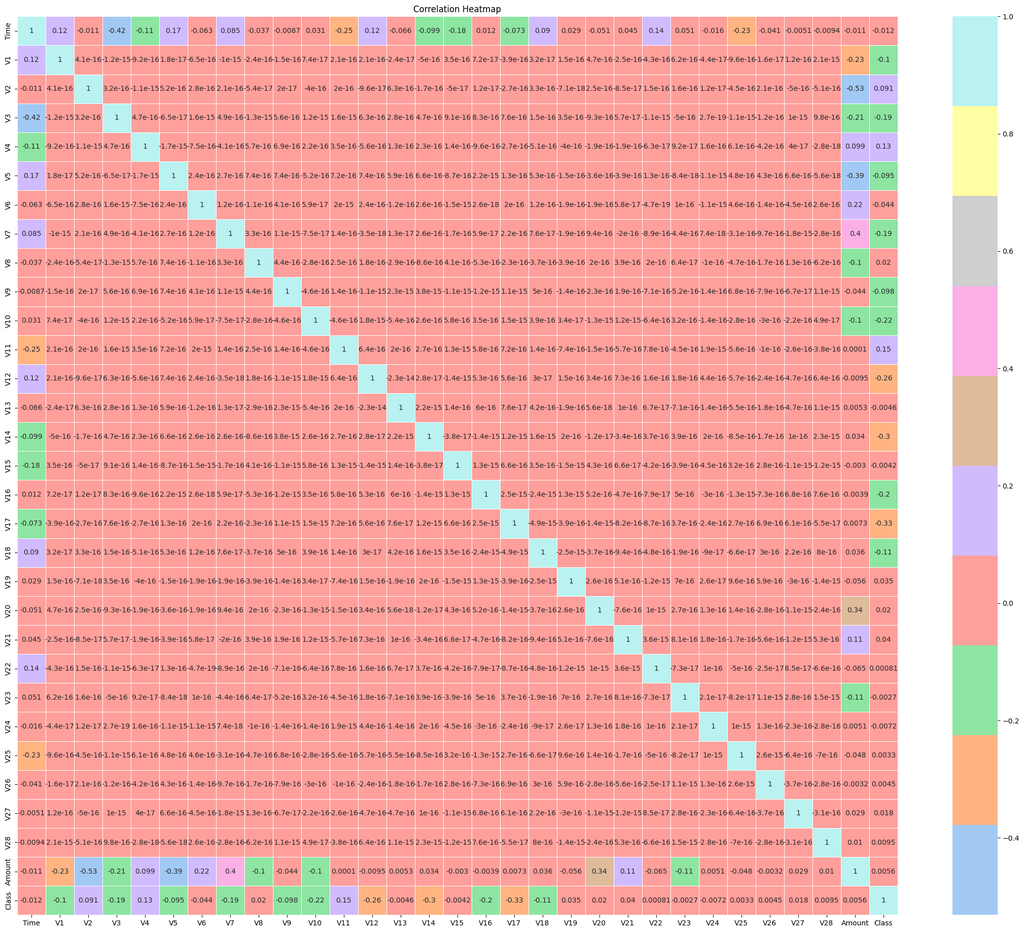

```python
# Create a correlation matrix
correlation_matrix = creditcard_g05.corr()

# Set a custom color palette (e.g., "coolwarm")
custom_palette = sns.color_palette("pastel")

# Create a heatmap with custom color palette
plt.figure(figsize=(28, 23))
sns.heatmap(correlation_matrix, annot=True, cmap=custom_palette, linewidths=0.5)
plt.title("Correlation Heatmap")
plt.show()
```

5. Show the Scatterplot matrix for the dataframe (avoid matplotlib and sns for this assignment). You can use Scatterplot Matrix Plotly. Use the code for the second image that shows different colors for classes. In this case, you will get two colors since we have two classes. Also, experiment with visual aspects of the image (not a lot, but an excellent visual will always leave a better impression. you can change color, thickness, font, font size, font color, etc.). No need to explain the plots but do save them in a pdf/svg/png with either static export function or html export function from plotly Interactive HTML Export Plotly. (10)

```python
import plotly.express as px
import random

# Randomly sample 20 features from the dataset (excluding the "Class" column for coloring)
all_features = list(creditcard_g05.columns.drop({"Class","Time","Amount"}))
selected_features = random.sample(all_features, 10)  # Using Python's random.sample

fig = px.scatter_matrix(creditcard_g05,
    dimensions=selected_features,
    color="Class",
    color_continuous_scale=["blue", "red"],  # Setting the color scale for the classification
    title="Credit Card Scatter Matrix"
    #template="plotly_dark"  # Using a dark theme for better aesthetics.
)

# Customize visual appearance
fig.update_traces(
    marker=dict(size=4, opacity=0.6)
)
fig.update_layout(
    font=dict(family="Courier New, monospace", size=14, color="white"),
    width=1000,
    height=800,
    dragmode='select',  # This allows users to select points interactively
    hovermode='closest'  # This shows the closest point's info on hover
)

fig.write_image("plot.pdf")
```

```python
fig.show()
```

[output not shown]

[output not shown]

6. Split the dataset into the Training set and Test set. Choose your preferred split and justify the rationale. (1)

```python
from sklearn.model_selection import train_test_split

# Assuming 'X' contains your feature columns and 'y' contains your target variable
credit_X = creditcard_g05.drop('Class', axis=1)  # Replace 'target_column' with your actual target column name
credit_y = creditcard_g05['Class']

# Split the dataset into a training set (80%) and a test set (20%)
creditx_train_g05, creditx_test_g05, credity_train_g05, credity_test_g05 = train_test_split(credit_X, credit_y, test_size=0.2, random_state=42)
```

7. Perform classification routine by using LogisticRegression(), KNeighborsClassifier(), DecisionTreeClassifier(), SVC(), GaussianNB(), RandomForestClassifier(), BaggingClassifier(), GradientBoostingClassifier(), XGboostclassifier. Output the accuracy box plot as we have seen in the class (make sure to change regressmod df to classmod. And use an appropriate metric for classification evaluation, for example, accuracy, precision,recall etc). Remember to use the object oriented approach and develop a function (def…), this will be very helpful for the next assignment. (40)

```python
import warnings
from sklearn.model_selection import cross_val_score, RepeatedKFold
from sklearn.linear_model import LogisticRegression
from sklearn.naive_bayes import GaussianNB
from sklearn.neighbors import KNeighborsClassifier
from sklearn.tree import DecisionTreeClassifier
from sklearn.ensemble import RandomForestClassifier, GradientBoostingClassifier, BaggingClassifier, StackingClassifier
from sklearn.svm import SVC
from xgboost import XGBClassifier
from sklearn.model_selection import train_test_split
from sklearn.compose import ColumnTransformer
from sklearn.preprocessing import OneHotEncoder
from sklearn.exceptions import ConvergenceWarning
warnings.filterwarnings("ignore", category=ConvergenceWarning)
warnings.filterwarnings("ignore")

def base_models():
  models = dict()
  models['Logistic'] = LogisticRegression(max_iter=10000)
  models["NB"] = GaussianNB()
  models["KNN"] = KNeighborsClassifier()
  models["Decision Tree"] = DecisionTreeClassifier()
  models["Random Forest"] = RandomForestClassifier()
  models["GB"] = GradientBoostingClassifier()
  models["XGB"] = XGBClassifier()
  models["Bagging"] = BaggingClassifier()
  models["SVM"] = SVC()
  return models

# Function to evaluate the list of models
def eval_models(model_g05):
  cv_g05 = RepeatedKFold(n_splits=5,n_repeats=3)
  scores_g05 = cross_val_score(model_g05, creditx_train_g05, credity_train_g05, scoring='accuracy', cv=cv_g05, n_jobs=-1,
                            error_score='raise')
  return scores_g05


models_g05 = base_models()
```

```python
# evaluate the models and store results


results_g05, names_g05 = list(), list()

for name, model in models_g05.items():
  scores_g05 = eval_models(model)
  results_g05.append(scores_g05)
  names_g05.append(name)
  print('>%s %.3f (%.3f)' % (name, scores_g05.mean(), scores_g05.std()))


classmod_g05 = pd.DataFrame(np.transpose(results_g05), columns = ["Logistic","NB","KNN","Decision Tree","Random Forest","GB","XGB","Bagging","SVM"])
classmod_g05 = pd.melt(classmod_g05.reset_index(), id_vars='index',value_vars=["Logistic","NB","KNN","Decision Tree","Random Forest","GB","XGB","Bagging","SVM"])
```

```
>Logistic 0.999 (0.000)
>NB 0.993 (0.000)
>KNN 0.998 (0.000)
>Decision Tree 0.999 (0.000)
>Random Forest 1.000 (0.000)
>GB 0.999 (0.000)
>XGB 1.000 (0.000)
>Bagging 1.000 (0.000)
>SVM 0.998 (0.000)
```

```python
from plotly.subplots import make_subplots
import plotly.graph_objs as go

fig_g05 = px.box(classmod_g05, x="variable", y="value",color="variable",points='all',
labels={"variable": "Machine Learning Model",
        "value": "Accuracy"
        },title="Model Performance")
fig_g05.show()
```

[output not shown]

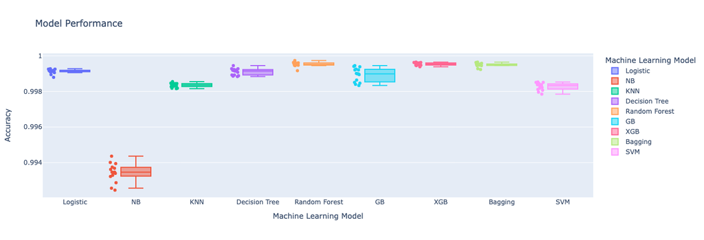

```python
from PIL import Image
from IPython.display import display

# Open an image file
image = Image.open('model_performance.png')

# Display the image (optional)
display(image)
```

8. Select the best classifier for level o classifier. Use logistic regression as a second level classifier. Similar to 5 generate the box plot and show the accuracy of each algorithm as well as stacked classifier. Also show the confusion metrices of the above algorithms .(15)

```python
import numpy as np

# Calculate the mean accuracy scores for all models
mean_scores = [np.mean(scores) for scores in results_g05]

# Sort the model names by mean accuracy scores in descending order
sorted_model_names = [name for _, name in sorted(zip(mean_scores, names_g05), reverse=True)]

# Select the top 4 models
best_models = sorted_model_names[:5]

print("The best base models are:")
for model_name in best_models:
    print(model_name)
```

```
The best base models are:
XGB
Random Forest
Bagging
Logistic
Decision Tree
```

```python
# Level-0 model list with best base model
level0 = list()
level0.append(('Tree', DecisionTreeClassifier()))
level0.append(('RF', RandomForestClassifier()))
level0.append(('Bagging', BaggingClassifier()))
level0.append(('XGB', XGBClassifier()))

# Level-1 model
level1 = LogisticRegression()

# Define stacked model
stacked_model = StackingClassifier(estimators=level0, final_estimator=level1, cv=5)

# Train the stacked model
stacked_model.fit(creditx_train_g05, credity_train_g05)
```

```
StackingClassifier(cv=5,
                   estimators=[('Tree', DecisionTreeClassifier()),
                               ('RF', RandomForestClassifier()),
                               ('Bagging', BaggingClassifier()),
                               ('XGB',
                                XGBClassifier(base_score=None, booster=None,
                                              callbacks=None,
                                              colsample_bylevel=None,
                                              colsample_bynode=None,
                                              colsample_bytree=None,
                                              device=None,
                                              early_stopping_rounds=None,
                                              enable_categorical=False,
                                              eval_metric=None,
                                              fea...
                                              interaction_constraints=None,
                                              learning_rate=None, max_bin=None,
                                              max_cat_threshold=None,
                                              max_cat_to_onehot=None,
                                              max_delta_step=None,
                                              max_depth=None, max_leaves=None,
                                              min_child_weight=None,
                                              missing=nan,
                                              monotone_constraints=None,
                                              multi_strategy=None,
                                              n_estimators=None, n_jobs=None,
                                              num_parallel_tree=None,
                                              random_state=None, ...))],
                   final_estimator=LogisticRegression())
```

```python
# Save to file in the current working directory
import pickle
pkl_filename = "../stack/AssignmentPickle.pkl"
with open(pkl_filename, 'wb') as file:
    pickle.dump(stacked_model, file)
```

```python
# Testing score with cross validation
scores_g05 = eval_models(stacked_model)
name = "Stacked model(Tree/RF/Bagging/XGB)"
results_g05.append(scores_g05)
names_g05.append(name)
print('>%s %.3f (%.3f)' % (name, scores_g05.mean(), scores_g05.std()))


stacked_mod_g05 = pd.DataFrame(np.transpose(results_g05), columns = ["Logistic","NB","KNN","Decision Tree","Random Forest","GB","XGB","Bagging","SVM","Stacked model"])
stacked_mod_g05 = pd.melt(stacked_mod_g05.reset_index(), id_vars='index',value_vars=["Logistic","NB","KNN","Decision Tree","Random Forest","GB","XGB","Bagging","SVM","Stacked model"])
```

```
>Stacked model(Tree/RF/Bagging/XGB) 1.000 (0.000)
```

```python
# choose best models and stacked model
stacked_mod_g05 = stacked_mod_g05[stacked_mod_g05['variable'].isin(["Decision Tree", "Random Forest", "XGB", "Bagging", "Stacked model"])]
```

```python
# box plot for stacked models
fig_g05 = px.box(stacked_mod_g05, x="variable", y="value",color="variable",points='all',
labels={"variable": "Machine Learning Model with second classfier = logistic regression",
        "value": "Accuracy"
        },title="Best models and Stacked Model Performance")
fig_g05.show()
```

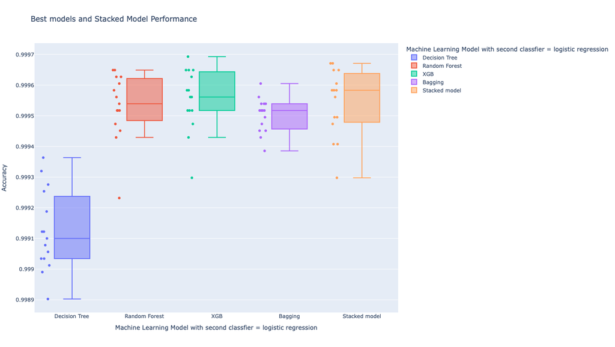

```python
from PIL import Image
from IPython.display import display

# Open an image file
image = Image.open('best_model.png')

# Display the image (optional)
display(image)
```

```python
from sklearn.metrics import confusion_matrix

# Load from file
with open(pkl_filename, 'rb') as file:
    pickle_model = pickle.load(file)

# Confusion Matrices
y_pred = stacked_model.fit(creditx_train_g05, credity_train_g05).predict(creditx_train_g05)
print(f"Confusion Matrix for Stacked {name} model:\n{confusion_matrix(credity_train_g05, y_pred)}\n")
```

```
Confusion Matrix for Stacked Stacked model(Tree/RF/Bagging/XGB) model:
[[227451      0]
 [     0    394]]
```

10. Show both text and visual confusion Matrices using scikit learn and matplotlib and explain what the graph tells you and what you did. (2)

```
Confusion Matrix:
[[227451      0]
 [     0    394]]
```

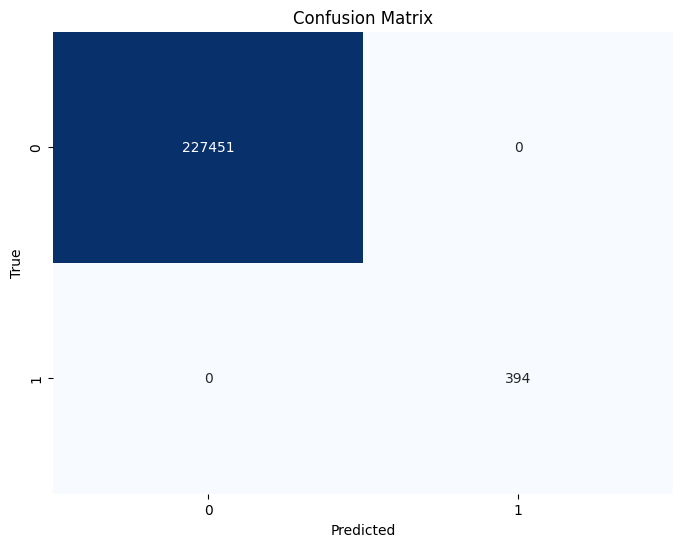

```python
import pickle
import matplotlib.pyplot as plt
import seaborn as sns
from sklearn.metrics import confusion_matrix

# Calculate the confusion matrix
conf_matrix = confusion_matrix(credity_train_g05, y_pred)

# Display the confusion matrix as text
print(f"Confusion Matrix:\n{conf_matrix}\n")

# Display the confusion matrix as a visual plot
plt.figure(figsize=(8, 6))
sns.heatmap(conf_matrix, annot=True, fmt='d', cmap='Blues', cbar=False)
plt.xlabel('Predicted')
plt.ylabel('True')
plt.title('Confusion Matrix')
plt.show()
```

As you can see in the image, there are 394 instances where the model correctly identified the positive class and there are 227,451 instances where the model correctly identified the negative class. Meanwhile, there are 0 false positives and false negatives, meaning the model did not make any incorrect predictions.